# README for Enhanced SFP Reports

Heather Hay c/o Optimization Team

February 02, 2022

[figure not shown]

### Pre-requisites

> - Your folder structure should be set up to mimic the layout in README_R_SETUP, like this example:

```
## [1] "C:/Users/HHAY/OneDrive - Government of BC/Optimization/Scripting/RStudio_Heather/.Rproj.user"
## [2] "C:/Users/HHAY/OneDrive - Government of BC/Optimization/Scripting/RStudio_Heather/figure"
## [3] "C:/Users/HHAY/OneDrive - Government of BC/Optimization/Scripting/RStudio_Heather/notes"
## [4] "C:/Users/HHAY/OneDrive - Government of BC/Optimization/Scripting/RStudio_Heather/output"
## [5] "C:/Users/HHAY/OneDrive - Government of BC/Optimization/Scripting/RStudio_Heather/scripts"
## [6] "C:/Users/HHAY/OneDrive - Government of BC/Optimization/Scripting/RStudio_Heather/source"
```

> - The raw data from OCIO should be cleaned using *clean_sfp_enhanced.py* and saved to the **source** folder (This step may be omitted in future updates)
> - The following 5 files should be in your **scripts** folder:
>   - enhanced_sfp_report_folder.rmd
>   - enhanced_sfp_report_share.rmd
>   - render_sfp_enhanced_report_folder.R
>   - render_sfp_enhanced_report_share.R
>   - GFX_OptimizationLogo-Icon_v2.png

### Reporting on an SFP share

> - open the file *render_sfp_enhanced_report_share.R*
> - change the bracketed text in the final line of the script to your desired parameters, like in this example:

```r
# render_report("2022-01-01_ENV_Enhanced_Data.csv", "S40183", "Q4", "FY21-22", "2021-12-22")
```

> - there are 5 mandatory fields to enter **in order**:
>   - the name of the csv file (you must include .csv in the file name)
>   - the name of the share
>   - the fiscal quarter (please format as Q# for consistency)
>   - the fiscal year (please format as FY##-## for consistency)
>   - the date on the raw data file from the OCIO, so clients have an idea of when the storage snapshot was taken
> - select all the text (ctrl-a) and then run the script by either pressing ctrl-Enter OR pressing the “Run” button in R Studio at the top right.

> The end result is 2 files in your **output** folder, named dynamically based on the parameters you input earlier.
> - SFP_Enhanced_Report_sharename_quarter_fiscalyear.xlsx
> - SFP_Enhanced_Report_sharename_quarter_fiscalyear.html

### Reporting on an SFP folder

> - open the file *render_sfp_enhanced_report_folder.R*
> - change the bracketed text in the final line of the script to your desired parameters, like in this example:

```r
# render_report("2021-04-01_ENV_SFP_Enhanced_Data.csv", "^\\\\\\\\SLEDGE\\\\S40203\\\\IRMT", "IRMT", "Q1", "FY21-22", "2021-04-27")
```

> - there are 6 mandatory fields to enter **in order**:
>   - the name of the csv file (you must include .csv in the file name)
>   - the folder path (please keep the caret and leading backslashes - there are 8 before the server and 4 before the share and each folder). If you have a folder name in your path that has parentheses in it, enclose the parentheses in square brackets so that they’re “escaped” from the regex expression. This also applies to the step below.  
>     i.e. ADMINISTRATION (100-499) needs square brackets around (100-499)
>   - the final folder name **exactly** as it is in the folder path. It is used as a “boundary” in the main script for when folder names are similar, but you only want to pull information from one of them. i.e. a simple filter on “ROB” might get you “ROB”, “ROB FOI”, and “ROBERTSON CREEK”, but having the boundary applied ensures you only get “ROB”.
>   - the fiscal quarter (please format as Q# for consistency)
>   - the fiscal year (please format as FY##-## for consistency)
>   - the date on the raw data file from the OCIO, so clients have an idea of when the storage snapshot was taken (please format as YYYY-MM-DD for consistency)
> - select all the text (ctrl-a) and then run the script by either pressing ctrl-Enter OR pressing the “Run” button in R Studio at the top right.

> The end result is 2 files in your **output** folder, named dynamically based on the parameters you input earlier.
> - SFP_Enhanced_Report_foldername_quarter_fiscalyear.xlsx
> - SFP_Enhanced_Report_foldername_quarter_fiscalyear.html

### Alternate Method of Running the Reports

> - open the file **enhanced_sfp_report_share.Rmd** or **enhanced_sfp_report_folder.Rmd**
> - press the arrow beside “Knit” and select “Knit with Parameters”
> - populate the fields in the resultant prompt window with your parameters, following the examples provided

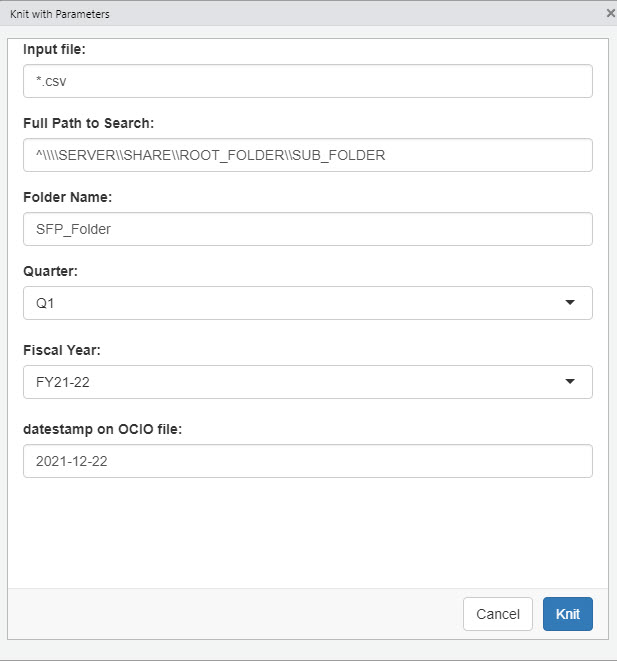

> - press “Knit”

> The end result is an excel file in your **output** folder (named dynamically based on the parameters you input earlier), and a html file in your **scripts** folder - it will have the same name as your script so be sure to rename it so it doesn’t get overwritten the next time you knit.
> - SFP_Enhanced_Report_foldername_quarter_fiscalyear.xlsx *or* SFP_Enhanced_Report_sharename_quarter_fiscalyear.xlsx
> - enhanced_sfp_report_share.html *or* enhanced_sfp_report_folder.html

### Reference Material

> [The here() package](https://github.com/jennybc/here_here)

> [An Introduction to R](https://intro2r.com/)

> [R for Data Science](https://r4ds.had.co.nz/)